# PM2.5 Prediction

Yazhuo Zhang

11/16/2018

```r
if (!require("pacman")) install.packages("pacman")
```

```r
pacman::p_load(
  "dummy",
  "corrplot",
  "matrixStats",
  "MASS",
  "glmnet",
  "leaps",
  "plyr",
  "gbm"
)
#load data
dataset = read.csv("PRSA_data_2010.1.1-2014.12.31.csv",sep = ",",header = TRUE)
set.seed(8)
#Check orignal dimension
dim(dataset)
```

```
## [1] 43824    13
```

```r
#detect missing value
NAcolumns = which(is.na(dataset))   #detect NA
dataset = na.omit(dataset) #Remove NA data from dataset
# lable encode for categorical variable cbwd
cbwd <- c('cv'=1,'NE'=2,'NW'=3,'SE'=4)
dataset$cbwd<-as.integer(revalue(dataset$cbwd, cbwd)) # revalue to replace categorical into numbers

#Add Yn-1 as lagged correlation
Y = dataset[,'pm2.5'] # Add Yn-1 as varaible to Yn time serie
Y = Y[1:length(Y)-1]
# Y_ = dataset[,'pm2.5']
# Y_ = Y_[1:length(Y_)-2]
dataset = dataset[2:nrow(dataset),]
dataset = cbind(dataset,Y)
```

Outlier and missing value detection From box plot and the plot between Y and PM2.5, I delete some outliers. There are some missing values in the column PM2.5. I delete the missing values.

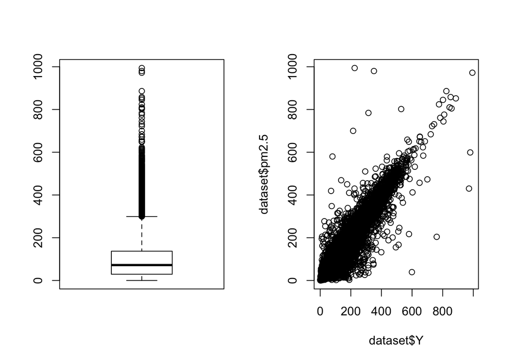

```r
#Plot Y and PM2.5
par(mfrow=c(1,2))
boxplot(dataset$pm2.5)
plot(dataset$Y,dataset$pm2.5)
```

```r
outliers = which(dataset$pm2.5>950) #965 16486 16487
dataset = dataset[-outliers,]
outliers_1 = which(dataset$Y<400&dataset$pm2.5>600)
outliers_2 = which(dataset$Y>=600&dataset$pm2.5<400)
outliers_3 = which(dataset$Y>800&dataset$pm2.5<600)
dataset = dataset[-outliers_1,]
dataset = dataset[-outliers_2,]
dataset = dataset[-outliers_3,]
```

Preprocess time attributes

```r
# Change year, month, day into Trigonometric formats
# helper function
day_of_year <- function(year,month,day){
  if(year%%4!=0){
    if(month==1)
      dayofyear = day
    if(month==2)
      dayofyear = 31+day
    if(month==3)
      dayofyear = 31+28+day
    if(month==4)
      dayofyear = 31+28+31+day
    if(month==5)
      dayofyear = 31+28+31+30+day
    if(month==6)
      dayofyear = 31+28+31+30+31+day
    if(month==7)
      dayofyear = 31+28+31+30+31+30+day
    if(month==8)
      dayofyear = 31+28+31+30+31+30+31+day
    if(month==9)
      dayofyear = 31+28+31+30+31+30+31+31+day
    if(month==10)
      dayofyear = 31+28+31+30+31+30+31+31+30+day
    if(month==11)
      dayofyear = 31+28+31+30+31+30+31+31+30+31+day
    if(month==12)
      dayofyear = 31+28+31+30+31+30+31+31+30+31+30+day
  }
  if(year%%4==0){
    if(month==1)
      dayofyear = day
    if(month==2)
      dayofyear = 31+day
    if(month==3)
      dayofyear = 31+29+day
    if(month==4)
      dayofyear = 31+29+31+day
    if(month==5)
      dayofyear = 31+29+31+30+day
    if(month==6)
      dayofyear = 31+29+31+30+31+day
    if(month==7)
      dayofyear = 31+29+31+30+31+30+day
    if(month==8)
      dayofyear = 31+29+31+30+31+30+31+day
    if(month==9)
      dayofyear = 31+29+31+30+31+30+31+31+day
    if(month==10)
      dayofyear = 31+29+31+30+31+30+31+31+30+day
    if(month==11)
      dayofyear = 31+29+31+30+31+30+31+31+30+31+day
    if(month==12)
      dayofyear = 31+29+31+30+31+30+31+31+30+31+30+day
  }
  return(dayofyear)
}
dataset = dataset[,2:ncol(dataset)]
day = rep(0,nrow(dataset))  # encode day column
for (i in c(1:nrow(dataset)))
{
  day[i] = day_of_year(dataset[i,1],dataset[i,2],dataset[i,3])
}
dataset[,'day'] = day
day  = dataset[,'day']
month = dataset[,'month']
hour = dataset[,'hour']
sin_month = sin(month*2*pi/12)
cos_month = cos(month*2*pi/12)
sin_day = 0
cos_day = 0
for (i in c(1:nrow(dataset))){
  if(dataset[i,'year']%%4!=0)
  {
    sin_day[i] = sin(day[i]*2*pi/365)
    cos_day[i] = cos(day[i]*2*pi/365)
  }
  if(dataset[i,'year']%%4==0)
  {
    sin_day[i] = sin(day[i]*2*pi/366)
    cos_day[i] = cos(day[i]*2*pi/366)
  }
}
sin_hour = sin(hour*2*pi/24)
cos_hour = cos(hour*2*pi/24)
dataset[,c('month','day','hour')] = NULL #Delete useless varaibles
dataset = cbind(dataset,sin_month,cos_month,sin_day,cos_day,sin_hour,cos_hour) #Combine all together
```

Show boxplot and histplot

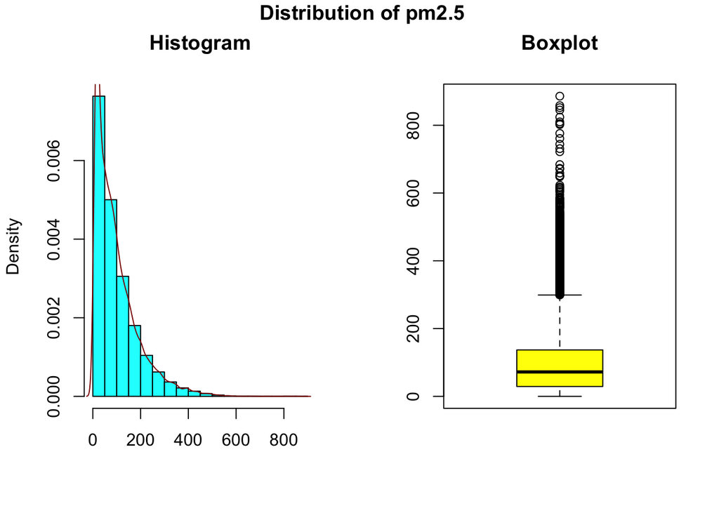

```r
par(mfrow= c(1,2))
hist(dataset$pm2.5, freq = FALSE, col = "cyan", main = "Histogram", xlab = "")
lines(density(dataset$pm2.5), col="darkred")
boxplot(dataset$pm2.5, main="Boxplot", col = "yellow")
title(outer = TRUE, main = "\n Distribution of pm2.5")
```

Feature selection: High correlated attributes can cause overfitting. According to correlation matrix and variable selectino, day and month are highly correlated and I delete sin_month and cos_month columns

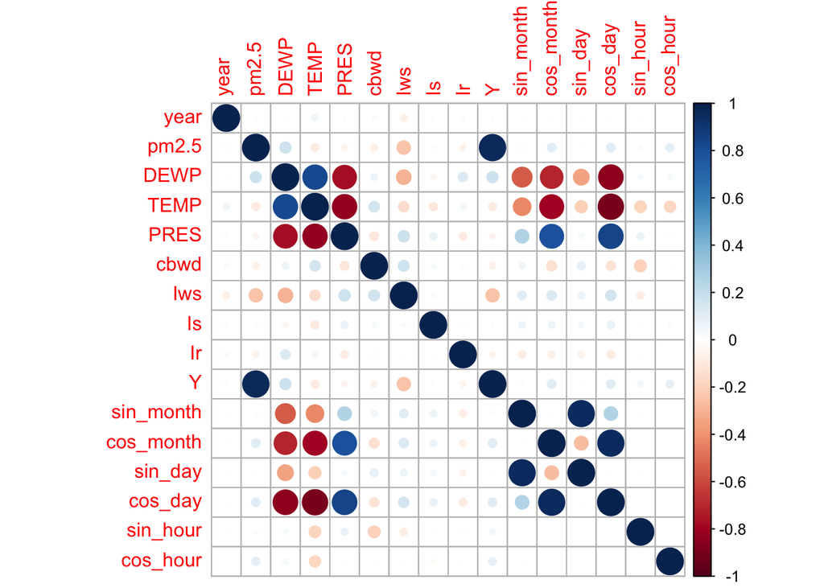

```r
correlation = cor(dataset)
par(mfrow=c(1,1))
corrplot(correlation, method="circle")
```

```r
dataset[,c('sin_month','cos_month')] = NULL
```

After preprocessing, there are 14 attributes and 41748 rows in the dataset.

```r
dim(dataset) #Check final dimension of dataset
```

```
## [1] 41748    14
```

Model Fitting: Train-test-split: seperate dataset into 80% train and 20%test

```r
Y = dataset[,'pm2.5']
X = dataset[,-2]
n = nrow(dataset)
ntest = round(n * 0.2) # Seperation training and test sets  80% / 20%
test.id = sample(1:n, ntest)
train_Y = Y[-test.id]
train_X = X[-test.id,]
test_Y = Y[test.id]
test_X = X[test.id,]
```

Prediction: Here I choose Linear Regression. Ridge, Lasso and GBM model to do prediction Linear models with stepwise AIC and BIC

```r
start_time = proc.time() # record start time of model training
fullmodel = lm('train_Y~.', data = as.data.frame(cbind(train_X,train_Y)))
# summary(fullmodel)
stepAIC = step(fullmodel, direction="both", trace = 0)
n = dim(train_X)[1]
stepBIC = step(fullmodel, direction="both", k=log(n),trace = 0)
LS_error = mean((train_Y-fullmodel$fitted.values)^2)
Ytest.pred = predict(fullmodel,newdata = test_X)
mean((Ytest.pred - test_Y)^2) #test error from linear regression
```

```
## [1] 503.2313
```

Ridge and LASSO Regression model

```r
lam.seq = exp(seq(-4, 4, length=100)) #tuning lambda for plots Ridge model
cv.out = cv.glmnet(as.matrix(train_X), as.matrix(train_Y), alpha = 0, lambda=lam.seq)
#plot(cv.out)
myridge = glmnet(as.matrix(train_X), as.matrix(train_Y), alpha=0, lambda = lam.seq)
Ytest.pred = predict(myridge, s = cv.out$lambda.min, newx=as.matrix(test_X))
mean((Ytest.pred - test_Y)^2)
```

```
## [1] 503.2042
```

```r
lam.seq = exp(seq(-6, 4, length=100))  #tuning lambda for plots LASSO model
cv.out = cv.glmnet(as.matrix(train_X), as.matrix(train_Y), alpha = 1, lambda=lam.seq)
#plot(cv.out)
mylasso = glmnet(as.matrix(train_X), as.matrix(train_Y), alpha=1, lambda = lam.seq)
Ytest.pred = predict(mylasso, s = cv.out$lambda.min, newx=as.matrix(test_X))
mean((Ytest.pred - test_Y)^2)
```

```
## [1] 503.2534
```

L1 norm penalty and L2 norm penalty do not give us better results. For tree model, I choose GBM to fit the model. After tuning, number of trees to fit the model is 400 and shrinkage of 0.05 with GBM library 2.1.3

```r
myfit1 = gbm(train_Y ~ . , data = cbind(train_X,train_Y),
             distribution = "gaussian",
             n.trees = 400,
             shrinkage = 0.05,
             interaction.depth = 3,
             bag.fraction = 1,
             cv.folds = 5)
gbm.perf(myfit1)
```

```
## [1] 400
```

```r
size = 1:myfit1$n.trees
test.err = rep(0, length(size))
for(i in 1:length(size)){
  y.pred = predict(myfit1, test_X, n.trees = size[i])
  test.err[i] = sum((test_Y - y.pred)^2)
}
opt.size = gbm.perf(myfit1)
```

[figure not shown]

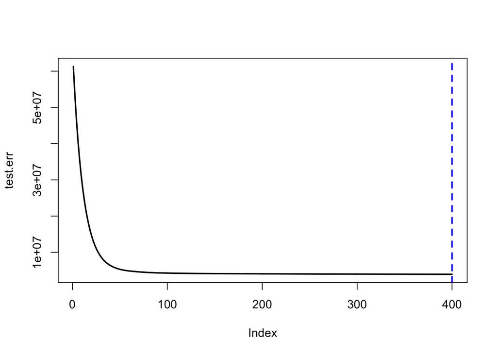

```r
plot(test.err, type = "n")
lines(size, test.err, lwd = 2)
abline(v = opt.size, lwd = 2, lty = 2, col = "blue")
```

```r
#Tune the n.trees to be the opt.size and calcuate error
Ytest.pred = predict(myfit1, test_X, n.trees = opt.size)
mean((Ytest.pred - test_Y)^2)
```

```
## [1] 472.9523
```

```r
print((proc.time() - start_time)[3]) #print running time for model fitting
```

```
## elapsed
##  40.599
```